Here's a plot made using the Munich rent dataset. It was made to explore the questions “how has the rent in Munich changed (from 1920 to 1990)” and “how does the proportion of centrally heated appartments change in time”.

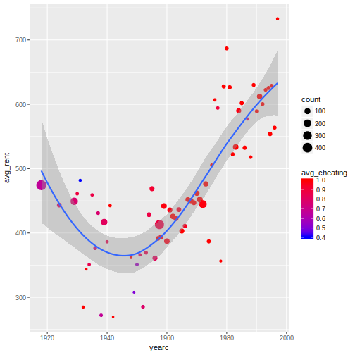

```r
library(tidyverse)
library(gamlss.data)

df <- rent99

rent_by_year <- summarise(group_by(df, yearc),
                          count=n(),
                          avg_rent=mean(rent, na.rm=TRUE),
                          avg_cheating=mean(as.numeric(cheating)-1, na.rm=TRUE))

ggplot(rent_by_year, aes(yearc, avg_rent)) +
  geom_point(aes(size=count,color=avg_cheating)) +
  geom_smooth() +
  scale_colour_gradient(low="#0000FF", high="#FF0000")
```

In the above plot, larger circles mean more rented appartments were registered in that year (meaning the average is computed for a larger n) and we therefore expect them to be closer to the true average for the given year. Smaller circles are less robust / more affected by variance. The general trend seems to be that rent decreased after WWI throughout WWII and has since increased. Almost all rented appartments after 1955 are centrally heated.

It's possible that the change in rent could be due to e.g. small appartments were rented during the 1930s and 1940s compared to 1920 and time closer to today. For any economical insight, it would be better to consider the rent per square meter. Indeed, plotting average area of rented appartments against year, we see that the distribution is not entirely uniform:

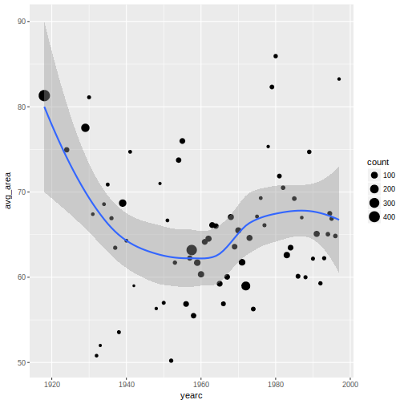

```r
area_by_year <- summarise(group_by(df, yearc),
                          count=n(),
                          avg_area=mean(area, na.rm=TRUE))

ggplot(area_by_year, aes(yearc, avg_area)) +
  geom_point(aes(size=count)) +
  geom_smooth()
```

So a better plot might be the following, where size of points is proportional to average flat size; less visible points correspond to years with lower count; and color is as before.

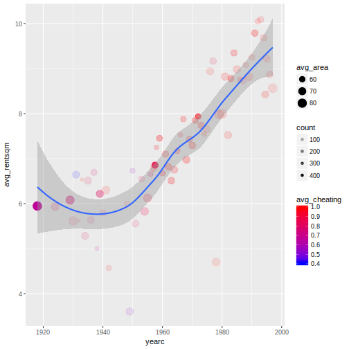

```r
rentsqm_by_year <- summarise(group_by(df, yearc),
                             count=n(),
                             avg_rentsqm=mean(rentsqm, na.rm=TRUE),
                             avg_area=mean(area, na.rm=TRUE),
                             avg_cheating=mean(as.numeric(cheating)-1, na.rm=TRUE))

ggplot(rentsqm_by_year, aes(yearc, avg_rentsqm)) +
  geom_point(aes(size=avg_area, alpha=count, color=avg_cheating)) +
  geom_smooth() +
  scale_colour_gradient(low="#0000FF", high="#FF0000")
```